# Function Overview

Lukas Burk

2020-06-01 UTC

This toolbox has been compiled to make the intro to R and statistics with R a little easier.  
Besides that, it also contains some neat helper functions for tasks or problems one might run in frequently in our field.

A neat overview of functions and stuff can be found [on tadaatoolbox.tadaa-data.de](http://tadaatoolbox.tadaa-data.de/)

# High Level Functions

There are several high level functions aimed at quick output generation:

- **tadaa_aov**
- **tadaa_balance**
- **tadaa_chisq**
- **tadaa_int**
- **tadaa_kruskal**
- **tadaa_levene**
- **tadaa_mean_ci**
- **tadaa_nom**
- **tadaa_one_sample**
- **tadaa_ord**
- **tadaa_pairwise_t**
- **tadaa_pairwise_tukey**
- **tadaa_plot_tukey**
- **tadaa_t.test**
- **tadaa_wilcoxon**
- **tadaa_z.test**

The point of these function is to combine routine steps into one function, so let’s showcase them.

## t-Tests: `tadaa_t.test`

The effect size $d$ is calculated with pooled/weighted variances to ensure accuracy. It then formats the output according to `broom::tidy`, sprinkles it with `pixiedust` and prints either to console, markdown or whatever printing method is passed via the `print` argument to `pixiedust::sprinkle_print_method`.

```r
tadaa_t.test(ngo, stunzahl, geschl, print = "markdown")
```

Table 1: **Welch Two Sample t-test** with alternative hypothesis: $\mu_1 \neq \mu_2$

| Diff | $\mu_1$ Männlich | $\mu_2$ Weiblich | t | SE | df | $CI_{95\%}$ | p | Cohen's d |
| --- | --- | --- | --- | --- | --- | --- | --- | --- |
| -0.05 | 33.62 | 33.66 | -0.11 | 0.44 | 242.1 | (-0.92 - 0.82) | .914 | -0.01 |

Or, if you’re having a non-parametric day, try this:

```r
tadaa_wilcoxon(ngo, stunzahl, geschl, print = "markdown")
```

Table 2: **Wilcoxon rank sum test with continuity correction** with alternative hypothesis: $M_1 \neq M_2$

| Difference | $M_1$ Männlich | $M_2$ Weiblich | W | p |
| --- | --- | --- | --- | --- |
| -1 | 33 | 34 | 7079.5 | .194 |

## ANOVA: `tadaa_aov`

The function knows 3 types of sums of squares, adjustable via the `type` argument and defaulting to type 3 sums of squares. Additionally for type 3, the function also automatically checks the contrasts associated with the factor variables (only for unordered factors), and if `check_names = TRUE`, the contrasts are set to `contr.sum`.

```r
tadaa_aov(stunzahl ~ jahrgang * geschl, data = ngo, print = "markdown")
```

Table 3: **Two-Way ANOVA**: Using Type III Sum of Squares

| Term | df | SS | MS | F | p | $\eta_\text{part}^2$ | Cohen’s f |
| --- | --- | --- | --- | --- | --- | --- | --- |
| geschl | 1 | 7.29 | 7.29 | 0.74 | .391 | 0 | 0.06 |
| jahrgang | 2 | 536.28 | 268.14 | 27.2 | < .001 | 0.18 | 0.47 |
| jahrgang:geschl | 2 | 96.06 | 48.03 | 4.87 | < .01 | 0.04 | 0.2 |
| Residuals | 244 | 2405.12 | 9.86 |  |  |  |  |
| Total | 249 | 3044.75 | 333.32 |  |  |  |  |

Or, if you’re still unsure about the parametricity of your day:

```r
tadaa_kruskal(stunzahl ~ jahrgang, data = ngo, print = "markdown")
```

Table 4: **Kruskal-Wallis Rank Sum Test**

| $\chi^2$ | df | p |
| --- | --- | --- |
| 20.89 | 2 | < .001 |

## Pairwise tests

### Pairwise t-tests

Since we found `stats::pairwise.t.test` insufficient in cases of two-way ANOVAs, we wrapped the function to also enable the testing of interactions. The adjusted p-values are only adjusted within each term, so it is like performing `stats::pairwise.t.test` 3 times with each factor and additionally the interaction of the two factors (which is what the function does internally).

As a bonus, this functions knows the two additional p-adjustment methods `sidak` and `sidakSD` for the Sidak adjustement and the Sidak-like step-down procedure respectively.

```r
tadaa_pairwise_t(ngo, response = deutsch, group1 = jahrgang, p.adjust = "bonf", print = "markdown")
```

| term | comparison | p (adj.) |
| --- | --- | --- |
| jahrgang | 12 - 11 | > .99 |
| jahrgang | 13 - 11 | < .01 |
| jahrgang | 13 - 12 | < .01 |

```r
tadaa_pairwise_t(ngo, response = deutsch, group1 = jahrgang, group2 = geschl, p.adjust = "sidakSD", print = "markdown")
```

| term | comparison | p (adj.) |
| --- | --- | --- |
| jahrgang | 12 - 11 | .86 |
| jahrgang | 13 - 11 | < .01 |
| jahrgang | 13 - 12 | < .01 |
| geschl | Weiblich - Männlich | < .001 |
| jahrgang:geschl | 12 & Männlich - 11 & Männlich | .287 |
| jahrgang:geschl | 13 & Männlich - 11 & Männlich | .121 |
| jahrgang:geschl | 11 & Weiblich - 11 & Männlich | < .001 |
| jahrgang:geschl | 12 & Weiblich - 11 & Männlich | .121 |
| jahrgang:geschl | 13 & Weiblich - 11 & Männlich | < .001 |
| jahrgang:geschl | 13 & Männlich - 12 & Männlich | .845 |
| jahrgang:geschl | 11 & Weiblich - 12 & Männlich | .189 |
| jahrgang:geschl | 12 & Weiblich - 12 & Männlich | .845 |
| jahrgang:geschl | 13 & Weiblich - 12 & Männlich | < .001 |
| jahrgang:geschl | 11 & Weiblich - 13 & Männlich | .845 |
| jahrgang:geschl | 12 & Weiblich - 13 & Männlich | .845 |
| jahrgang:geschl | 13 & Weiblich - 13 & Männlich | < .05 |
| jahrgang:geschl | 12 & Weiblich - 11 & Weiblich | .398 |
| jahrgang:geschl | 13 & Weiblich - 11 & Weiblich | .12 |
| jahrgang:geschl | 13 & Weiblich - 12 & Weiblich | < .01 |

# Statistics Wrappers

These are pretty self-explanatory. The goal is to provide simple functions for commonly used statistics that look and behave the same, and also only return a single numerical value to play nice with `dplyr::summarize`.

- `modus`: A simple function to extract the mode of a frequency table.
- `nom_chisqu`: Simple wrapper for `chisq.test` that produces a single value.
- `nom_phi`: Simple wrapper for `vcd::assocstats` to extract phi.
- `nom_v`: Simple wrapper for `vcd::assocstats` to extract Cramer’s V.
- `nom_c`: Simple wrapper for `vcd::assocstats` to extract the contingency coefficient c.
- `nom_lambda`: Simple wrapper for `ryouready::nom.lambda` to extract appropriate lambda.
- `ord_gamma`: Simple wrapper for `ryouready::ord.gamma`.
- `ord_somers_d`: Simple wrapper for `ryouready::ord.somers.d`.

## Summaries

- `tadaa_nom`: All the nominal stats in one table.
- `tadaa_ord`: All the ordinal stats in one table.

# General Helper Functions

## Intervals and recoding

- `generate_recodes`: To produce recode assignments for `car::recode` for evenly sequenced clusters.
- `interval_labels`: To produce labels for clusters created by `cut`.
- `delete_na`: Customizable way to drop `NA` observations from a dataset.
- `pval_string`: Shamelessly adapted from `pixiedust::pvalString`, this will format a p-value as a character string in common `p < 0.001` notation and so on. The difference from the `pixiedust` version is that this function will also print `p < 0.05`.

## Plotting helpers

- `mean_ci_t`: Returns a `data.frame` with `y` (`mean`), `ymin` and `ymax` for the CI bounds.
  - `confint_t`: For the underlying function to get the CI width. Returns a single value.
  - `confint_norm`: Similar, but baes on normal distribution. Returns a single value.
- `mean_ci_sem`: Standard error and CI, you guessed it, in one table.

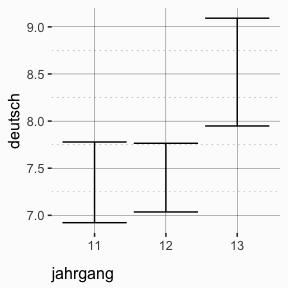

```r
library(ggplot2)

ggplot(data = ngo, aes(x = jahrgang, y = deutsch)) +
  stat_summary(fun.data = "mean_ci_t", geom = "errorbar") +
  theme_tadaa()
```

As a convenience, we added `tadaa_mean_ci` to quickly plot means with errorbars to get a quick glance at your data.

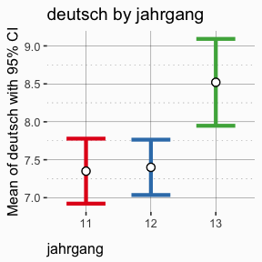

```r
tadaa_mean_ci(data = ngo, response = deutsch, group = jahrgang) +
  theme_tadaa()
```

### Prebuilt plotting functions

- `tadaa_int`: Simple interaction plot template.

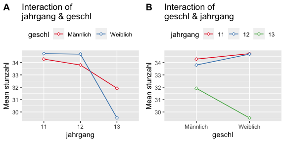

```r
library(ggplot2)
if (!("cowplot" %in% installed.packages())) install.packages("cowplot")

tadaa_int(data = ngo, response = stunzahl, group1 = jahrgang, group2 = geschl, grid = T, brewer_palette = "Set1")
```

# Data

The infamous *ngo* dataset is included for teaching purposes as well. It differs from ryouready’s provided version with regards to classes and labels. The code below was used to generate the provided version of the dataset:

(Note that `\u00e4` is a unicode encoded Umlaut for compatibility reasons)

```r
ngo <- ryouready::d.ngo

## sjPlot value labels
ngo$geschl   <- sjmisc::set_labels(ngo$geschl,   c("M\u00e4nnlich", "Weiblich"))
ngo$abschalt <- sjmisc::set_labels(ngo$abschalt, c("Ja", "Nein"))
ngo$jahrgang <- sjmisc::set_labels(ngo$jahrgang, c("11", "12", "13"))
ngo$hausauf  <- sjmisc::set_labels(ngo$hausauf,  c("gar nicht", "weniger als halbe Stunde",
                                                   "halbe Stunde bis Stunde", "1 bis 2 Stunden",
                                                   "2 bis 3 Stunden", "3 bis 4 Stunden",
                                                   "mehr als 4 Stunden"))

## factors
ngo$geschl   <- factor(ngo$geschl,   labels = c("M\u00e4nnlich", "Weiblich"))
ngo$jahrgang <- factor(ngo$jahrgang, labels = c("11", "12", "13"), ordered = TRUE)
ngo$hausauf  <- car::recode(ngo$hausauf,  "0 = NA")
ngo$abschalt <- car::recode(ngo$abschalt, "0 = NA")
ngo$abschalt <- factor(ngo$abschalt, labels = c("Ja", "Nein"))

## Variable labels
ngo$geschl   <- sjmisc::set_label(ngo$geschl, "Geschlecht")
ngo$abschalt <- sjmisc::set_label(ngo$abschalt, "Abschalten")
ngo$jahrgang <- sjmisc::set_label(ngo$jahrgang, "Jahrgang")
ngo$hausauf  <- sjmisc::set_label(ngo$hausauf, "Hausaufgaben")

## Saving
ngo <- dplyr::tbl_df(ngo)
```